# Medidas de Tendencia Central

Estadística Descriptiva

10/19/2020

Las medidas de tendencia central son medidas estadísticas que pretenden resumir en un solo valor a un conjunto de valores. Representan un centro en torno al cual se encuentra ubicado el conjunto de los datos.

Las medidas de tendencia central pueden calcularse tanto para una población como para una muestra de ésta. Las medidas numéricas que se calculan sobre los datos de la población se conocen como **parámetros** , y **estadísticos** cuando se refieren a la muestra.

Las medidas de tendencia central más utilizadas son: **media**, **mediana** y **moda**.

## Parámetro y Estadístico

Un **parámetro** es la medida numérica que se calcula a partir de los datos observados en una población.

Un **estadístico** es la medida numérica que se calcula a partir de los datos observados en una muestra.

## Media Aritmética

La **media aritmética**, también conocida como *promedio*, es una medida que prácticamente todas las personas conocen, al menos a nivel intuitivo, y se calcula sumando el total de los datos o valores de la variable para luego dividir esa suma entre el número de datos sumados. A esa medida común se le llama indistintamente **media**, promedio o media aritmética. Por ejemplo, si se tienen 5 personas cuyas edades son 15, 18, 25, 33 y 64 años, la media aritmética o promedio de edades de este grupo sería:

$$\textrm{Media aritmética} = \frac{15 + 18 + 25 + 33 + 64}{5} = 31$$

Por lo general, la media se denota con la letra $x$ con una barra arriba, es decir, $\overline{x}$. El resumen del procedimiento para calcular la media de una muestra se puede plantear mediante la siguiente fórmula:

$$\overline{x} = \frac{\sum_{i=1}^n x_i}{n}$$

La media de la muestra $\overline{x}$ es un estadístico , en tanto que la media correspondiente a la población se denota por la letra griega ($\mu$) y es un parámetro . En la práctica, es difícil obtener este parámetro por cuestiones económicas y porque, en general, es poco viable y por lo tanto $\mu$ es desconocido. Así $\overline{x}$ se puede calcular, puesto que los datos de la muestra están disponibles.

La fórmula para la media poblacional es la siguiente:

$$\mu = \frac{\sum_{i=1}^N x_i}{N}$$

Donde $N$ es el número total de individuos en la población a estudiar.

En resumen, considerando las ecuaciones anteriores se tiene:

| Población | *Parámetro* $\mu$ | Medida: media poblacional: | $\mu$ |
| --- | --- | --- | --- |
| Muestra | *Estadístico* $\overline{x}$ | Medida: media muestral | $\overline{x}$ |

Para hallar la media aritmética en el lenguaje R es bastante sencillo. Supóngase que hemos recolectado la cantidad de lluvia que ha caido en cierta zona en el mes de julio de 8 años. Queremos hallar el promedio.

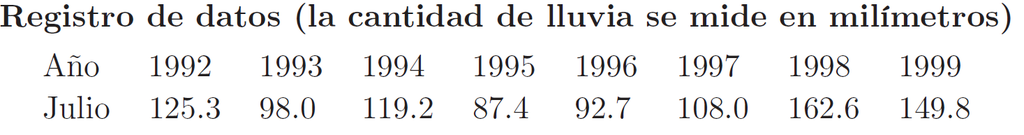

Datos

```r
# Guardamos los datos a promediar en un vector
x <- c(125.3, 98.0, 119.2, 87.4, 92.7, 108.0, 162.6, 149.8)

# Y hallamos el promedio facilmente
media_x <- mean(x)

# Mostramos la media de x
print(media_x)
```

```
## [1] 117.875
```

### Características de interés para la muestra

- Algunos se refieren a ella como promedio; desde luego se usa de manera frecuente y resulta un valor de referencia.
- Siempre existe y esta medida toma en cuenta cada valor.
- La media se ve afectada por valores extremos.
- Debido a que satisface ciertas propiedades matemáticas, esta medida tiene un buen desempeño en muchos métodos estadísticos.

## La media ponderada

La *media ponderada* es una medida de interés, inicialmente el cálculo de la media considera que cada valor de la variable es de igual importancia. Sin embargo, en diferentes situaciones es de interés darle mayor peso a alguno de los valores observados $x_i$. En ese sentido cada valor se multiplica por el peso, $w_i$, que se le dé a la observación, se suman estos valores y se divide entre la suma de los pesos. Esto se obtiene mediante la siguiente expresión:

$$\overline{x} = \frac{\sum_{i=1}^n w_ix_i}{\sum_{i=1}^n w_i}$$

> La *media ponderada* es una medida de tendencia central que toma en consideración la importancia relativa de los valores observados.

**Ejemplo**

Un administrador desea darle mayor peso a la comisión de sus vendedores debido al tipo de cliente que visitan. En este caso tienen determinadas cuatro zonas, en la zona 1 tendrá el doble, la zona 2 el triple, en la zona 3 no se tiene comisión extra y en la zona 4 se quintuplica. La variable $X$ es las ventas, en miles de pesos, realizadas en cada zona, los valores observados son 82, 60, 140, 35. ¿Cuál es la media ponderada de ventas?

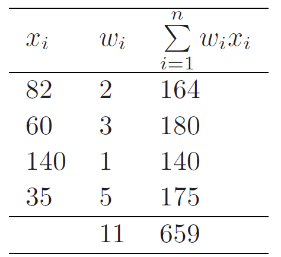

Media Ponderada

Ahora, si queremos hallar el promedio ponderado, dividimos los dos resultados presentados en la tabla:

$$\overline{x} = \frac{\sum_{i=1}^n w_ix_i}{\sum_{i=1}^n w_i} = \frac{659}{11} = 59.909$$

Para hallar esta medida en el lenguaje R utilizamos la función `weighted.mean` de la siguiente manera.

```r
# Guardamos las ventas en una variable: ventas
ventas <- c(82, 60, 140, 35)

# Y guardamos los pesos de cada variable en otro vector: pesos
pesos <- c(2, 3, 1, 5)

# Encontramos e imprimimos el promedio ponderado
media_ponderada <- weighted.mean(ventas, pesos)
print(media_ponderada)
```

```
## [1] 59.90909
```

## Mediana

La **mediana** es el valor que ocupa el lugar central en una serie ordenada.

El procedimiento para encontrar la mediana es el siguiente:

- Se ordenan los datos de menor a mayor.
- Se localiza la observación que está exactamente a la mitad de la posición.
  - Si el número $n$ de observaciones es impar, la mediana es el valor correspondiente a la posición $(n + 1)/2$.
  - Si el número n de observaciones es par, la mediana es la media de los valores que están en las posiciones $n/2$ y $(n/2) + 1$.

**Ejemplo**

Once pacientes necesitaron esperar varios minutos para que los atendieran en la clínica de su localidad, aunque hicieron una cita previa. Para cada paciente, el plazo respectivo de espera en minutos, los valores de la variable son:

$$38, 42, 36, 40, 44, 45, 42, 36, 43, 39 \textrm{ y } 42$$
Hallemos la *mediana* del tiempo de espera.

**Etapa 1** Se ordenan los datos de menor a mayor. Como se observa en la tabla que aparece abajo, en el segundo renglón se ordenan los datos y en el primero se describe la posición en que quedan éstos después de ordenarlos.

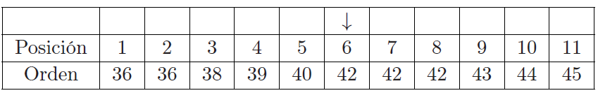

**Etapa 2** Se localiza la observación que está exactamente a la mitad de la posición. En este caso, como es número impar, el número que está a la mitad se obtiene por la expresión: $(11+1)/2=6$. La observación que está en la posición $6$, en este caso $42$, es la mediana de los datos, esto es:

$$\widetilde{m} = 42$$

La interpretación de este problema es que la mitad de los pacientes esperan menos de 42 minutos para entrar a la consulta y la otra mitad más de 42 minutos, lo que en términos reales resulta una demora considerable.

Para calcular en R la *mediana* de un conjunto de datos, utilizamos la función `median`.

```r
# Guardamos los datos en un vector: tiempos_espera
tiempos_espera <- c(38, 42, 36, 40, 44, 45, 42, 36, 43, 39, 42)

# Hallamos la mediana y la imprimimos
mediana <- median(tiempos_espera)
print(mediana)
```

```
## [1] 42
```

En general no se da una expresión para la mediana de la población, aquí la consideramos con el fin de tener presente la idea de la relación población y muestra.

Entre las características de interés para la mediana se encuentran las siguientes: * tiene un uso frecuente; * siempre existe y no toma en cuenta cada valor; * no se ve afectada por valores extremos, y es apropiada en estos casos.

## Moda

La **moda** es otra medida de tendencia central y ésta se define como el valor de la observación que más veces se repite en la muestra (o en la población); es decir, el de mayor frecuencia, y se denotará por $m_o$.

**Ejemplo**

La administración de una universidad quiere evaluar la calidad de la comida que ofrece la cafetería a sus estudiantes, para decidir si renueva el contrato a la empresa de alimentos que tiene contratada. Se aplica una encuesta a una muestra de estudiantes que acuden a comer con regularidad a la cafetería. A los estudiantes se les pidió que calificaran la calidad de la comida en una escala de 1 a 5, donde 1 es extremadamente mala y 5 extremadamente buena. Los resultados son:

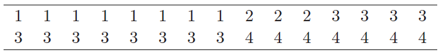

1. ¿Cuál es la media de la calificación?
2. ¿Cuál es la mediana de la calificación?
3. ¿Cuál es la moda de esta calificación?
4. Con la información, ¿se puede decir que los estudiantes entrevistados tienen una opinión favorable, neutral o desfavorable para la calidad en la comida?

**Solución**

1. La media es

$$\overline{x} = \frac{\sum_{i=1}^{30} x_i}{30} = \frac{78}{30} = 2.6$$

2. Como se tienen 30 datos, la mediana es la media de las observaciones que están en las posiciones: $\frac{30}{2} = 15$ y $\frac{30}{2} + 1 = 16$, es decir, $\frac{3+3}{2} = 3$
3. La tabla de frecuencia para los datos es:

| calificaciones | Freq |
| --- | --- |
| 1 | 8 |
| 2 | 3 |
| 3 | 12 |
| 4 | 7 |

Como podemos observar en la tabla anterior, la calificación que posee la mayor frecuencia es el $3$, por lo tanto, esta será la moda de nuestro conjunto de datos.

4. **Interpretación**

Tanto la mediana como la moda permiten concluir que los estudiantes tienen una posición neutral para la calidad de la comida. En términos de la media, la opinión es ligeramente desfavorable, ya que está por debajo de la calificación neutral de 3.

### Cálculo de la moda en R

Para el cálculo de la moda, debe haberse instalado previamente el paquete `modeest` y haberlo cargado en la sesión de trabajo; esto permitirá contar con una función que calculará de forma automática el o los valores más frecuentes de la variable, herramienta que no existe en los paquetes básicos de R. Así, para el ejercicio anterior, se utiliza el comando `mfv` para calcular la moda de la variable `calificaciones`. El resultado de este comando indica el valor, o los valores, con más frecuencia dentro de la distribución de casos de la variable señalada.

```r
library(modeest)

calificaciones <- c(1, 1, 1, 1, 1, 1, 1, 1, 2, 2, 2, 3, 3, 3, 3,
                    3, 3, 3, 3, 3, 3, 3, 3, 4, 4, 4, 4, 4, 4, 4)

mean(calificaciones)
```

```
## [1] 2.6
```

```r
median(calificaciones)
```

```
## [1] 3
```

```r
mfv(calificaciones)
```

```
## [1] 3
```